## Anàlisi descriptiva després del preprocessing

### Anàlisi univariant de les variables

Per la part de l’anàlisi descriptiva després del preprocessing, en vista que els resultats són molt similars a aquells d’abans del preprocessing, no es farà una anàlisi en profunditat de cada gràfic, sinó que es remetrà a l’anàlisi d’abans del preprocessing per als gràfics que es presenten. A la part d’anàlisi descriptiva bivariant, en canvi, sí que s’estudiaran tots els gràfics.

**Variables categòriques**

S’ha afegit una variable nova, Unknown, que conté les dades faltants. Com que els missings s’han creat artificialment perquè representin només el 5% de la variable, l’addició de la variable Unknown no provoca canvis significatius en la descriptiva.

En les variables categòriques, la diferència més notòria és que les classes amb més percentatge es veuen reduïdes per la variable Unknown.

*COURSE*

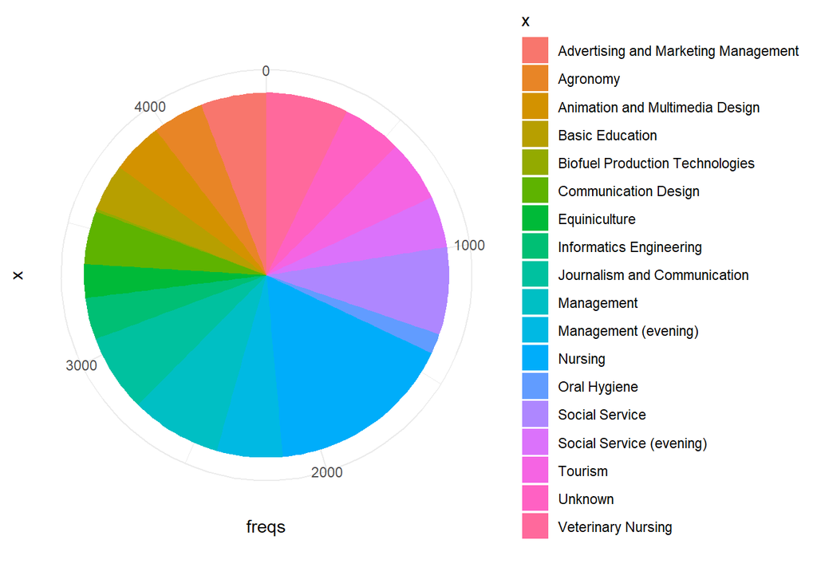

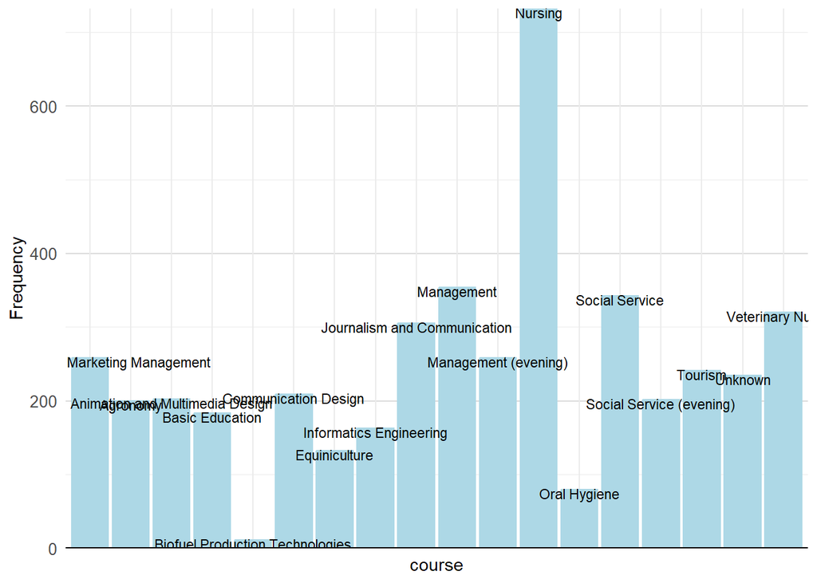

```
##
## --------------------------------------------------------------------------
## Variable   Stats / Values                   Freqs (% of Valid)   Missing
## ---------- -------------------------------- -------------------- ---------
## course\    1\. Advertising and Marketing\   258 ( 5.8%)\         0\
## [factor]   2\. Agronomy\                    200 ( 4.5%)\         (0.0%)
##            3\. Animation and Multimedia \   202 ( 4.6%)\
##            4\. Basic Education\             183 ( 4.1%)\
##            5\. Biofuel Production Techno\   11 ( 0.2%)\
##            6\. Communication Design\        209 ( 4.7%)\
##            7\. Equiniculture\               132 ( 3.0%)\
##            8\. Informatics Engineering\     163 ( 3.7%)\
##            9\. Journalism and Communicat\   305 ( 6.9%)\
##            10\. Management\                 354 ( 8.0%)\
##            [ 8 others ]                     2407 (54.4%)
## --------------------------------------------------------------------------
```

*DAYTIME_ATTENDANCE*

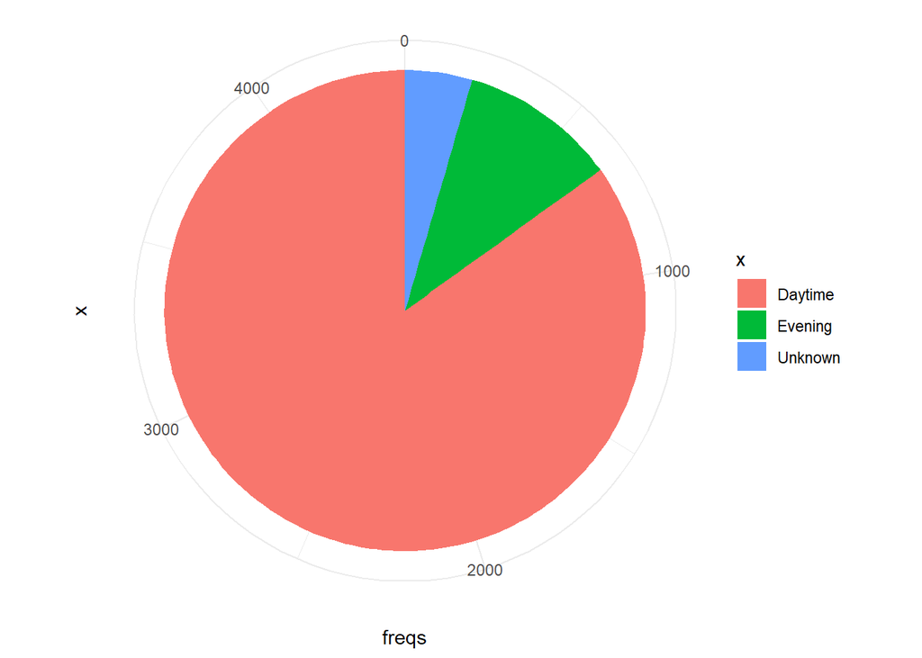

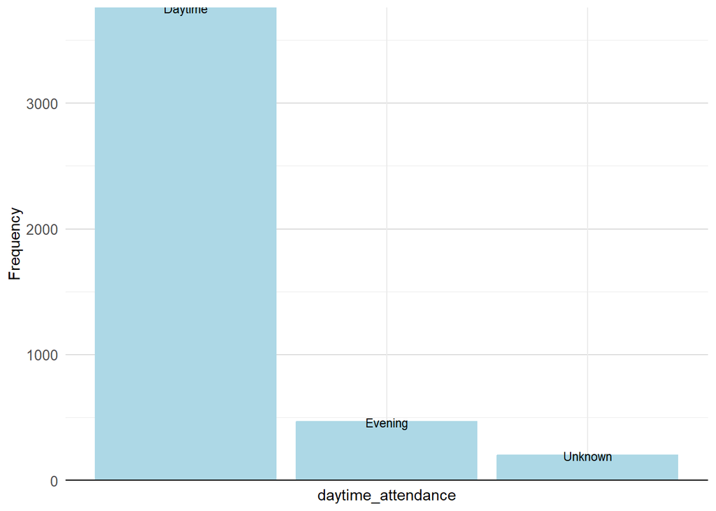

```
##
## ---------------------------------------------------------------------
## Variable              Stats / Values   Freqs (% of Valid)   Missing
## --------------------- ---------------- -------------------- ---------
## daytime_attendance\   1\. Daytime\     3758 (84.9%)\        0\
## [factor]              2\. Evening\     467 (10.6%)\         (0.0%)
##                       3\. Unknown      199 ( 4.5%)
## ---------------------------------------------------------------------
```

*NATIONALITY*

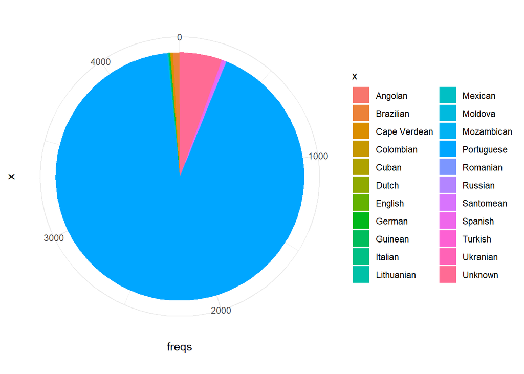

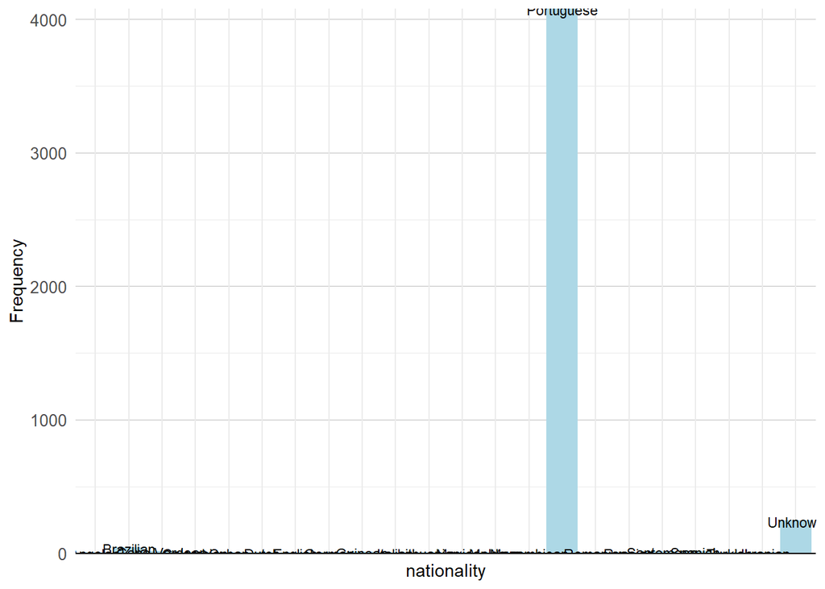

```
##
## -----------------------------------------------------------------
## Variable       Stats / Values      Freqs (% of Valid)   Missing
## -------------- ------------------- -------------------- ---------
## nationality\   1\. Angolan\        2 ( 0.0%)\           0\
## [factor]       2\. Brazilian\      37 ( 0.8%)\          (0.0%)
##                3\. Cape Verdean\   13 ( 0.3%)\
##                4\. Colombian\      1 ( 0.0%)\
##                5\. Cuban\          1 ( 0.0%)\
##                6\. Dutch\          1 ( 0.0%)\
##                7\. English\        1 ( 0.0%)\
##                8\. German\         2 ( 0.0%)\
##                9\. Guinean\        5 ( 0.1%)\
##                10\. Italian\       3 ( 0.1%)\
##                [ 12 others ]       4358 (98.5%)
## -----------------------------------------------------------------
```

*OCCUPATION_MOTHER*

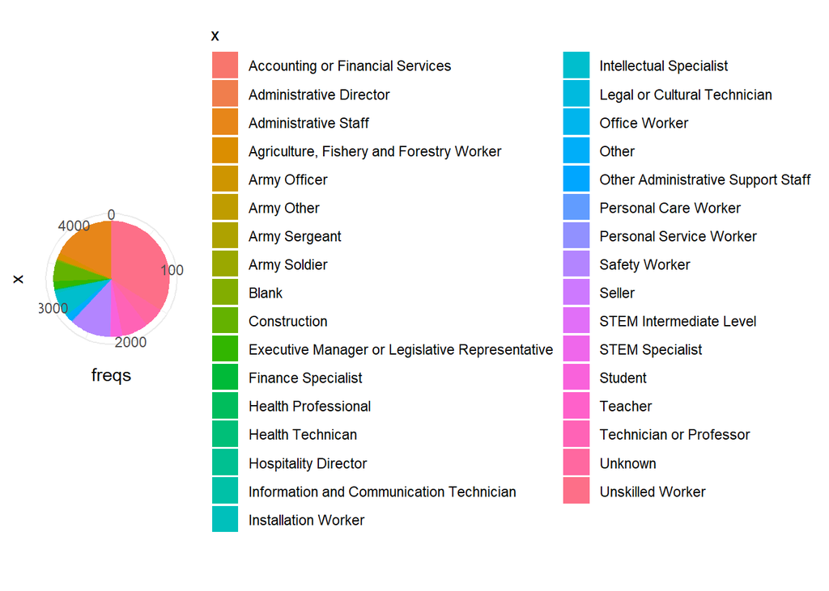

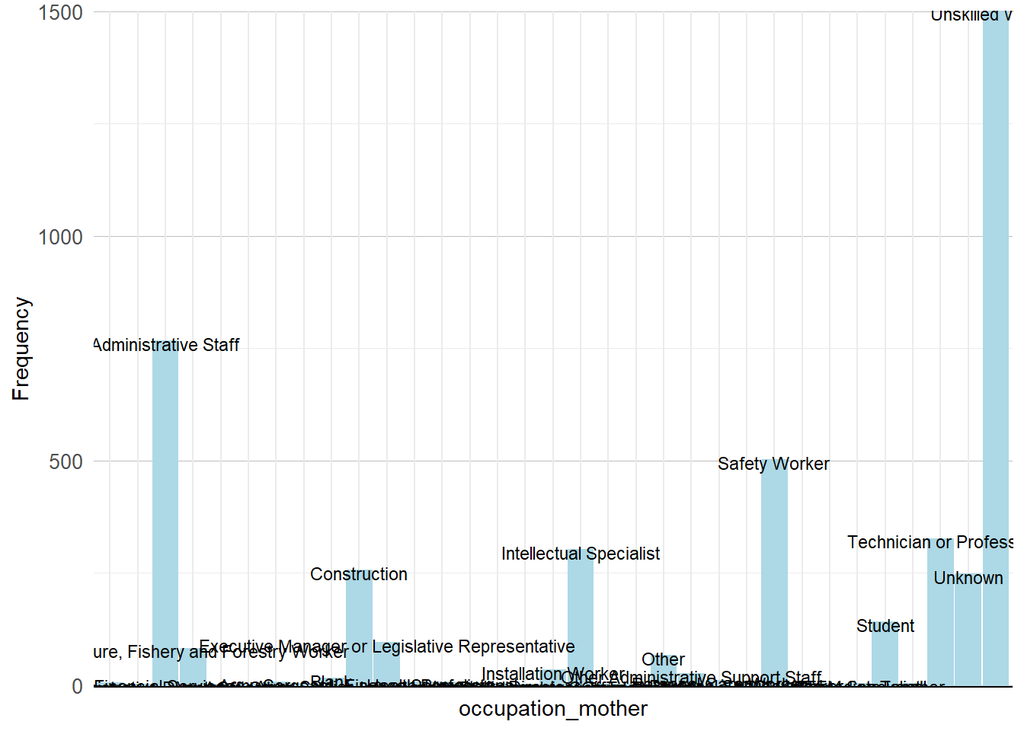

```
##
## ------------------------------------------------------------------------------------
## Variable             Stats / Values                   Freqs (% of Valid)   Missing
## -------------------- -------------------------------- -------------------- ---------
## occupation_mother\   1\. Accounting or Financial S\   5 ( 0.1%)\           0\
## [factor]             2\. Administrative Director\     1 ( 0.0%)\           (0.0%)
##                      3\. Administrative Staff\        765 (17.3%)\
##                      4\. Agriculture, Fishery and \   82 ( 1.9%)\
##                      5\. Army Officer\                2 ( 0.0%)\
##                      6\. Army Other\                  1 ( 0.0%)\
##                      7\. Army Sergeant\               7 ( 0.2%)\
##                      8\. Army Soldier\                3 ( 0.1%)\
##                      9\. Blank\                       15 ( 0.3%)\
##                      10\. Construction\               256 ( 5.8%)\
##                      [ 23 others ]                    3287 (74.3%)
## ------------------------------------------------------------------------------------
```

*OCCUPATION_FATHER*

[figure not shown]

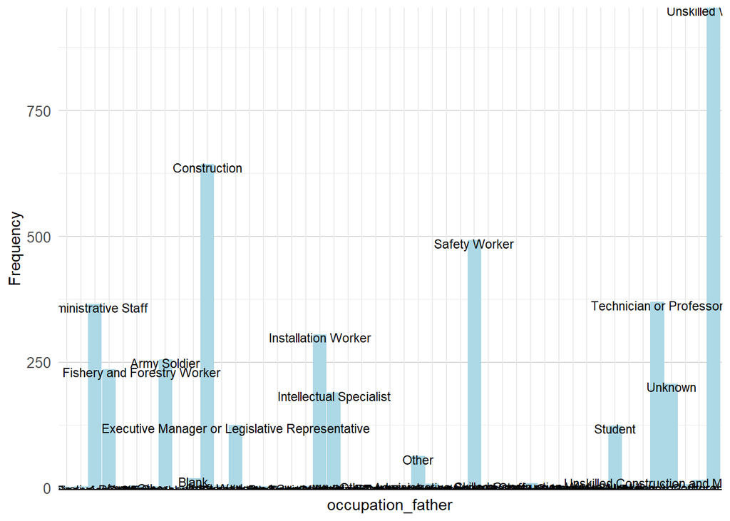

```
##
## ------------------------------------------------------------------------------------
## Variable             Stats / Values                   Freqs (% of Valid)   Missing
## -------------------- -------------------------------- -------------------- ---------
## occupation_father\   1\. Accounting or Financial S\   1 ( 0.0%)\           0\
## [factor]             2\. Administrative Director\     2 ( 0.0%)\           (0.0%)
##                      3\. Administrative Staff\        364 ( 8.2%)\
##                      4\. Agriculture, Fishery and \   235 ( 5.3%)\
##                      5\. Army Officer\                1 ( 0.0%)\
##                      6\. Army Other\                  4 ( 0.1%)\
##                      7\. Army Sergeant\               2 ( 0.0%)\
##                      8\. Army Soldier\                254 ( 5.7%)\
##                      9\. Assembly Worker\             1 ( 0.0%)\
##                      10\. Blank\                      18 ( 0.4%)\
##                      [ 37 others ]                    3542 (80.1%)
## ------------------------------------------------------------------------------------
```

*SPECIAL_NEEDS*

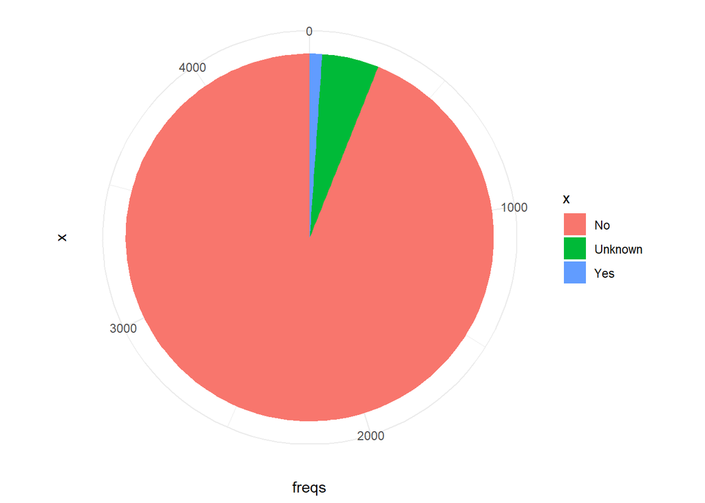

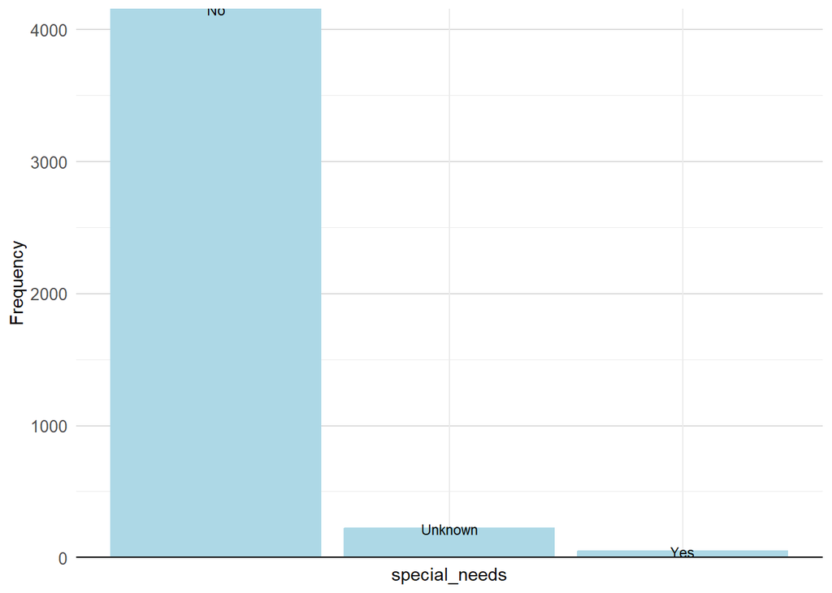

```
##
## ----------------------------------------------------------------
## Variable         Stats / Values   Freqs (% of Valid)   Missing
## ---------------- ---------------- -------------------- ---------
## special_needs\   1\. No\          4155 (93.9%)\        0\
## [factor]         2\. Unknown\     221 ( 5.0%)\         (0.0%)
##                  3\. Yes          48 ( 1.1%)
## ----------------------------------------------------------------
```

*GENDER*

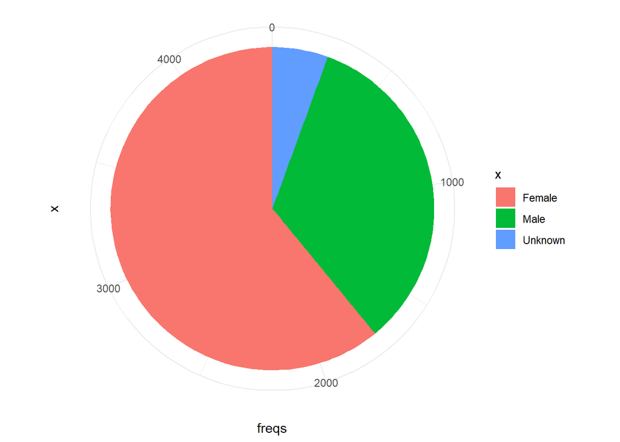

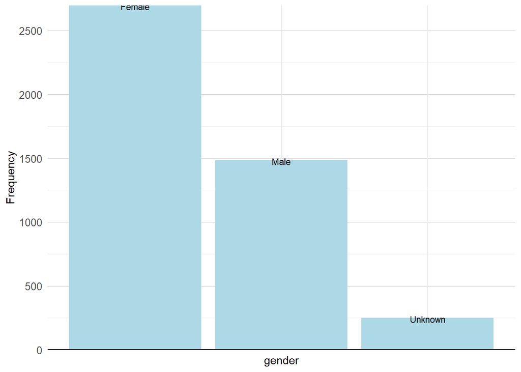

```
##
## ----------------------------------------------------------
## Variable   Stats / Values   Freqs (% of Valid)   Missing
## ---------- ---------------- -------------------- ---------
## gender\    1\. Female\      2696 (60.9%)\        0\
## [factor]   2\. Male\        1482 (33.5%)\        (0.0%)
##            3\. Unknown      246 ( 5.6%)
## ----------------------------------------------------------
```

*SCHOLARSHIP*

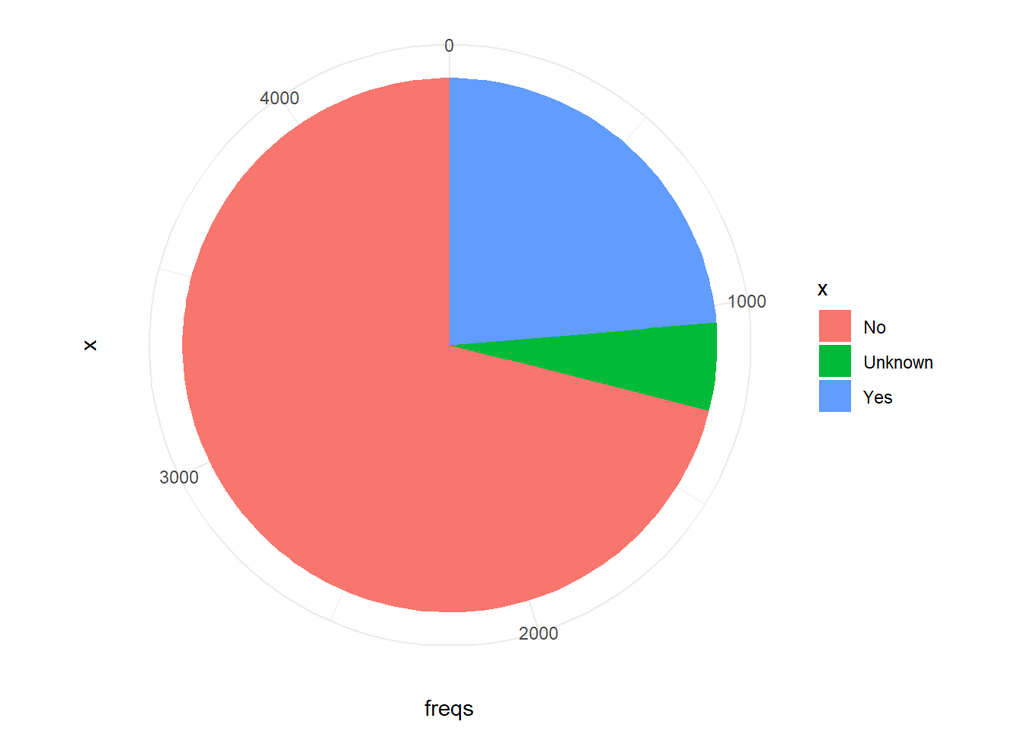

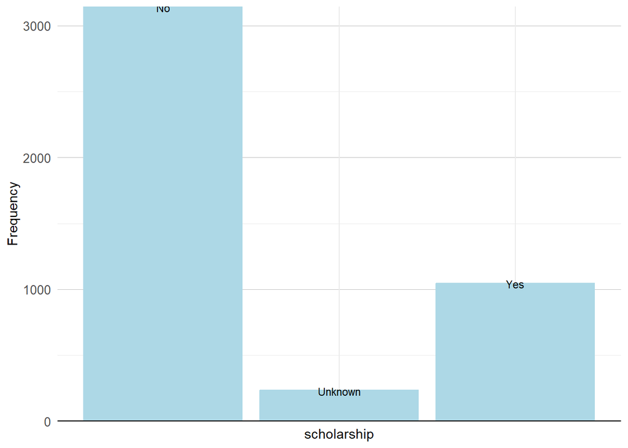

```
##
## --------------------------------------------------------------
## Variable       Stats / Values   Freqs (% of Valid)   Missing
## -------------- ---------------- -------------------- ---------
## scholarship\   1\. No\          3144 (71.1%)\        0\
## [factor]       2\. Unknown\     233 ( 5.3%)\         (0.0%)
##                3\. Yes          1047 (23.7%)
## --------------------------------------------------------------
```

*TARGET*

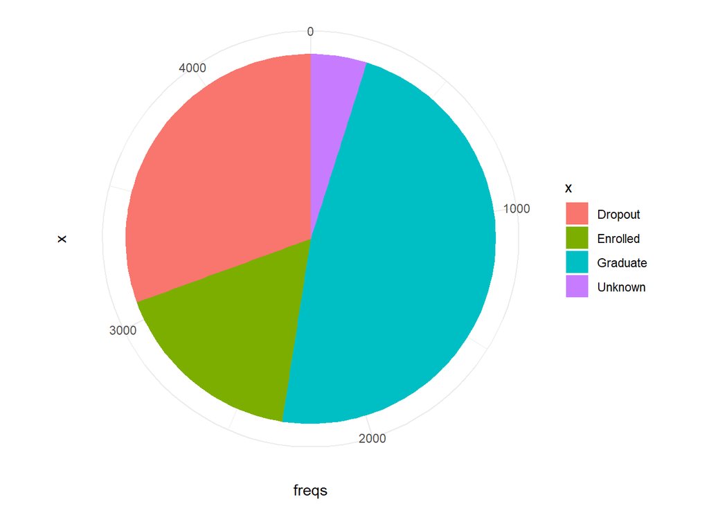

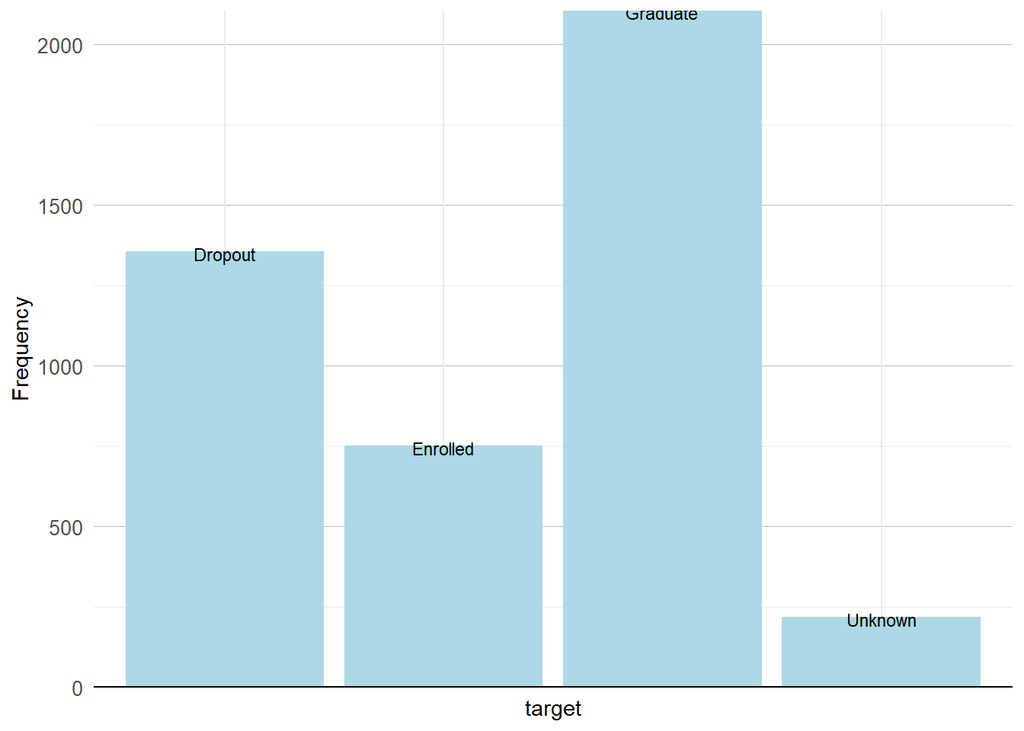

```
##
## ----------------------------------------------------------
## Variable   Stats / Values   Freqs (% of Valid)   Missing
## ---------- ---------------- -------------------- ---------
## target\    1\. Dropout\     1353 (30.6%)\        0\
## [factor]   2\. Enrolled\    750 (17.0%)\         (0.0%)
##            3\. Graduate\    2104 (47.6%)\
##            4\. Unknown      217 ( 4.9%)
## ----------------------------------------------------------
```

*PREVIOUS_QUALIFICATION*

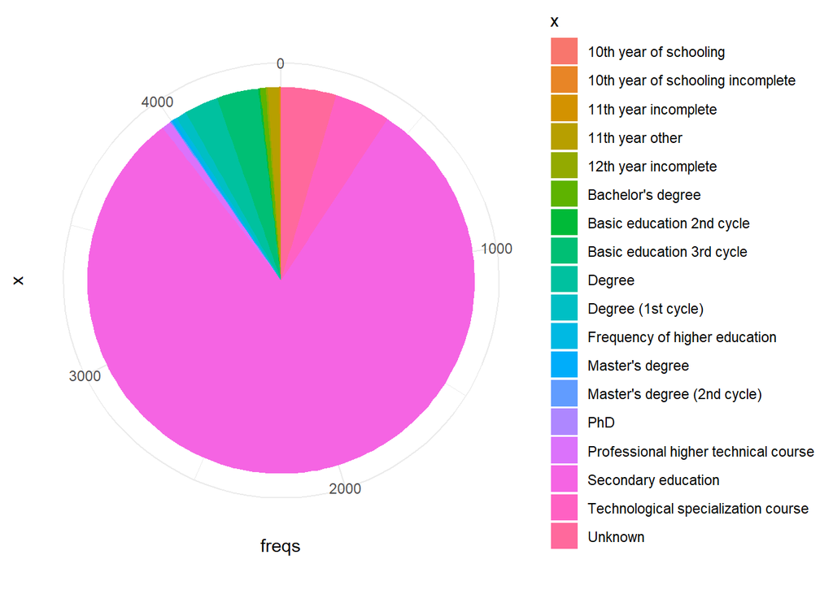

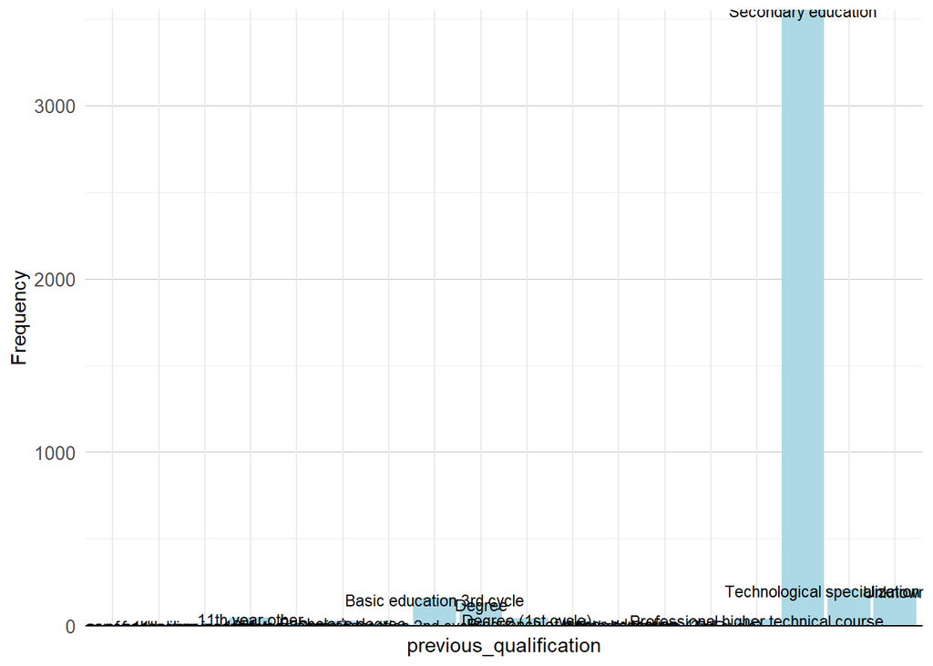

```
##
## -----------------------------------------------------------------------------------------
## Variable                  Stats / Values                   Freqs (% of Valid)   Missing
## ------------------------- -------------------------------- -------------------- ---------
## previous_qualification\   1\. 10th year of schooling\      1 ( 0.0%)\           0\
## [factor]                  2\. 10th year of schooling in\   2 ( 0.0%)\           (0.0%)
##                           3\. 11th year incomplete\        4 ( 0.1%)\
##                           4\. 11th year other\             42 ( 0.9%)\
##                           5\. 12th year incomplete\        8 ( 0.2%)\
##                           6\. Bachelor's degree\           20 ( 0.5%)\
##                           7\. Basic education 2nd cycle\   7 ( 0.2%)\
##                           8\. Basic education 3rd cycle\   154 ( 3.5%)\
##                           9\. Degree\                      125 ( 2.8%)\
##                           10\. Degree (1st cycle)\         38 ( 0.9%)\
##                           [ 8 others ]                     4023 (90.9%)
## -----------------------------------------------------------------------------------------
```

**Variables numèriques**

En les variables numèriques tampoc s’observen canvis significatius. El més destacable és que la mediana de la taxa d’inflació ha baixat de 1.4% a 1% i la mitjana del PIB ha variat de 0.003% a 0.011%.

*AGE*

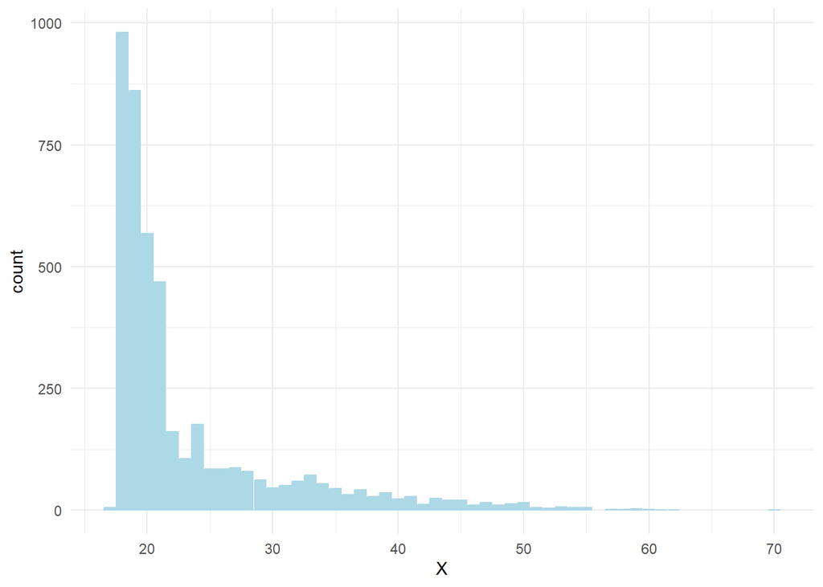

```
##
## | N.Valid  |  Min   |   Q1   | Median |  Mean  | Std.Dev |   Q3   |  Max   |  IQR  |
## |:--------:|:------:|:------:|:------:|:------:|:-------:|:------:|:------:|:-----:|
## | 4424.000 | 17.000 | 19.000 | 20.000 | 23.244 |  7.426  | 24.000 | 70.000 | 5.000 |
```

*GRADES_SEM_1*

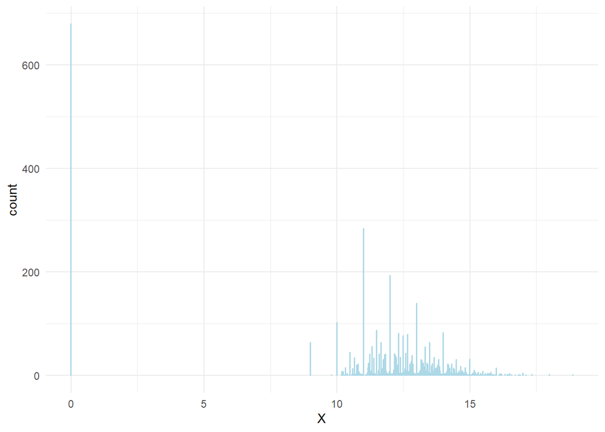

```
##
## | N.Valid  |  Min  |   Q1   | Median |  Mean  | Std.Dev |   Q3   |  Max   |  IQR  |
## |:--------:|:-----:|:------:|:------:|:------:|:-------:|:------:|:------:|:-----:|
## | 4424.000 | 0.000 | 11.000 | 12.170 | 10.629 |  4.717  | 13.330 | 18.880 | 2.330 |
```

*NO_EVAL_SEM_1*

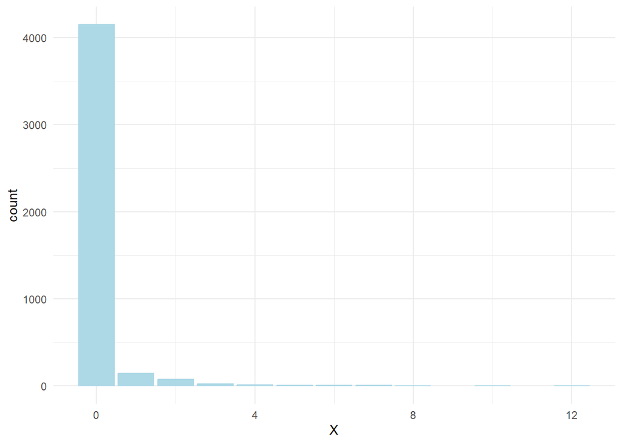

```
##
## | N.Valid  |  Min  |  Q1   | Median | Mean  | Std.Dev |  Q3   |  Max   |  IQR  |
## |:--------:|:-----:|:-----:|:------:|:-----:|:-------:|:-----:|:------:|:-----:|
## | 4424.000 | 0.000 | 0.000 | 0.000  | 0.130 |  0.677  | 0.000 | 12.000 | 0.000 |
```

*GRADES_SEM_2*

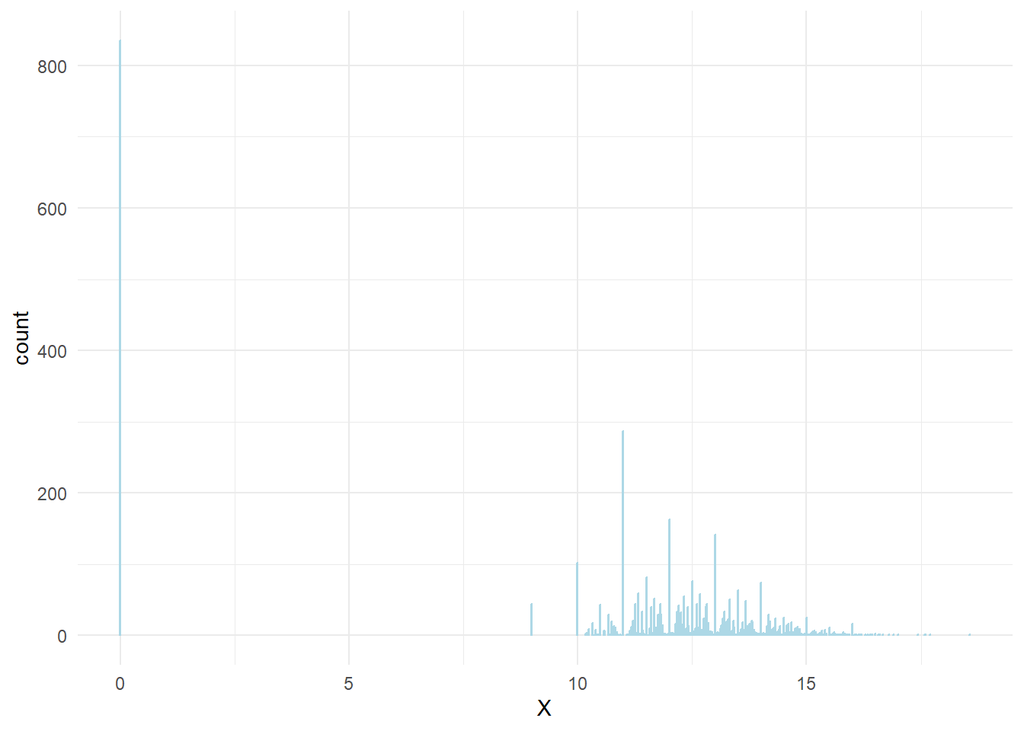

```
##
## | N.Valid  |  Min  |   Q1   | Median |  Mean  | Std.Dev |   Q3   |  Max   |  IQR  |
## |:--------:|:-----:|:------:|:------:|:------:|:-------:|:------:|:------:|:-----:|
## | 4424.000 | 0.000 | 10.670 | 12.070 | 10.222 |  5.101  | 13.300 | 18.570 | 2.630 |
```

*NO_EVAL_SEM_2*

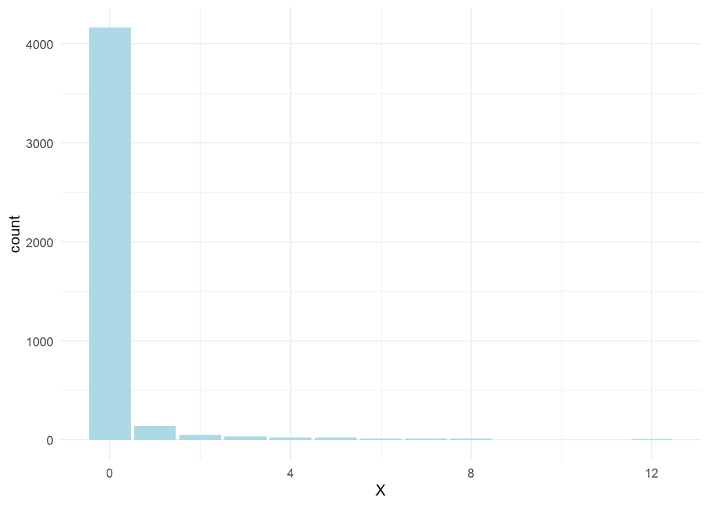

```
##
## | N.Valid  |  Min  |  Q1   | Median | Mean  | Std.Dev |  Q3   |  Max   |  IQR  |
## |:--------:|:-----:|:-----:|:------:|:-----:|:-------:|:-----:|:------:|:-----:|
## | 4424.000 | 0.000 | 0.000 | 0.000  | 0.141 |  0.731  | 0.000 | 12.000 | 0.000 |
```

*UNEMPLOYMENT_RATE*

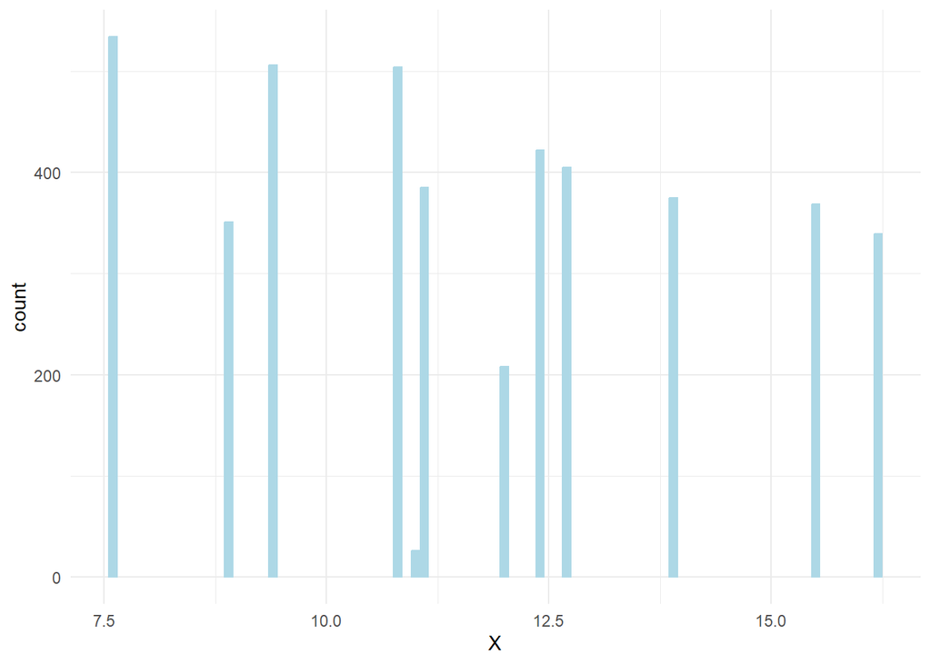

```
##
## | N.Valid  |  Min  |  Q1   | Median |  Mean  | Std.Dev |   Q3   |  Max   |  IQR  |
## |:--------:|:-----:|:-----:|:------:|:------:|:-------:|:------:|:------:|:-----:|
## | 4424.000 | 7.600 | 9.400 | 11.100 | 11.582 |  2.584  | 12.700 | 16.200 | 3.300 |
```

*INFLATION_RATE*

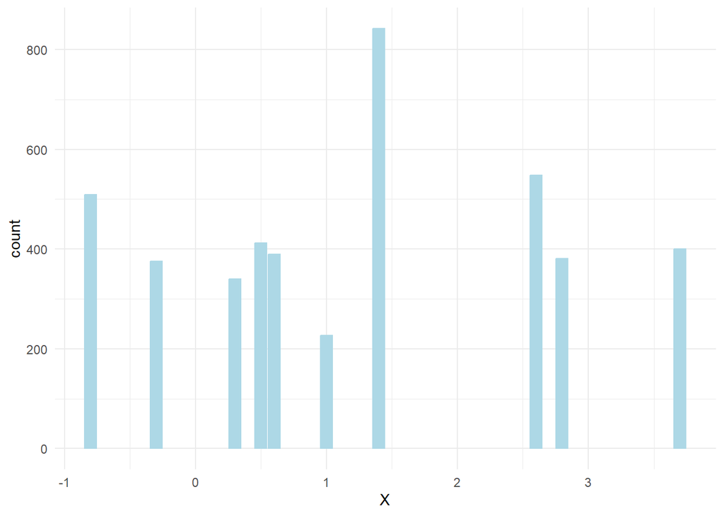

```
##
## | N.Valid  |  Min   |  Q1   | Median | Mean  | Std.Dev |  Q3   |  Max  |  IQR  |
## |:--------:|:------:|:-----:|:------:|:-----:|:-------:|:-----:|:-----:|:-----:|
## | 4424.000 | -0.800 | 0.300 | 1.000  | 1.221 |  1.352  | 2.600 | 3.700 | 2.300 |
```

*GDP*

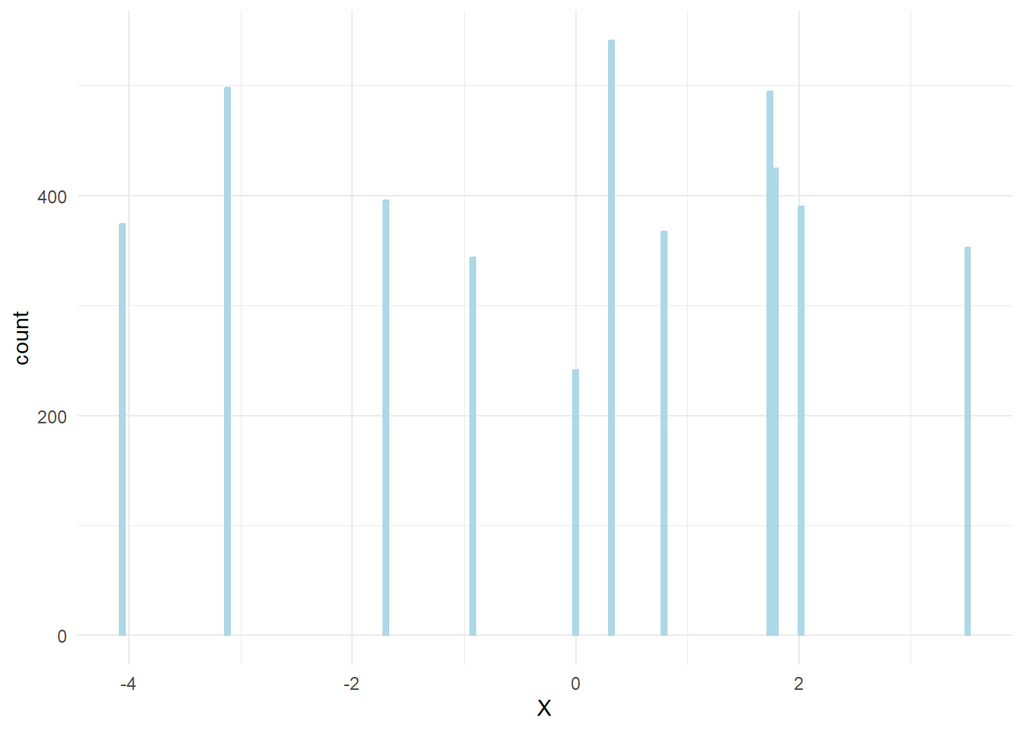

```
##
## | N.Valid  |  Min   |   Q1   | Median | Mean  | Std.Dev |  Q3   |  Max  |  IQR  |
## |:--------:|:------:|:------:|:------:|:-----:|:-------:|:-----:|:-----:|:-----:|
## | 4424.000 | -4.060 | -1.700 | 0.320  | 0.011 |  2.206  | 1.790 | 3.510 | 3.490 |
```

### Anàlisi bivariant

**Dues variables numèriques**

*AGE* i *GRADES_SEM_1*

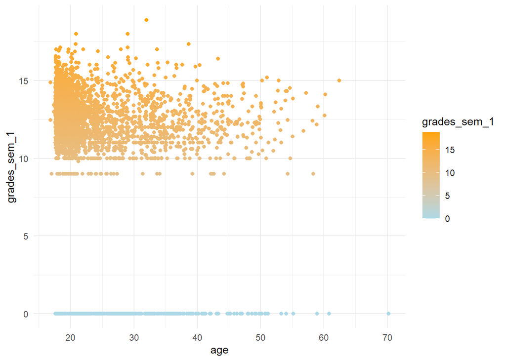

En funció de l’edat, s’observa que no hi ha diferències significatives a la nota del primer semestre. És possible que, en entrar en una edat més avançada (dels 50 endavant) hi hagi menys tendència a les notes excel·lents.

*AGE* i *GRADES_SEM_2*

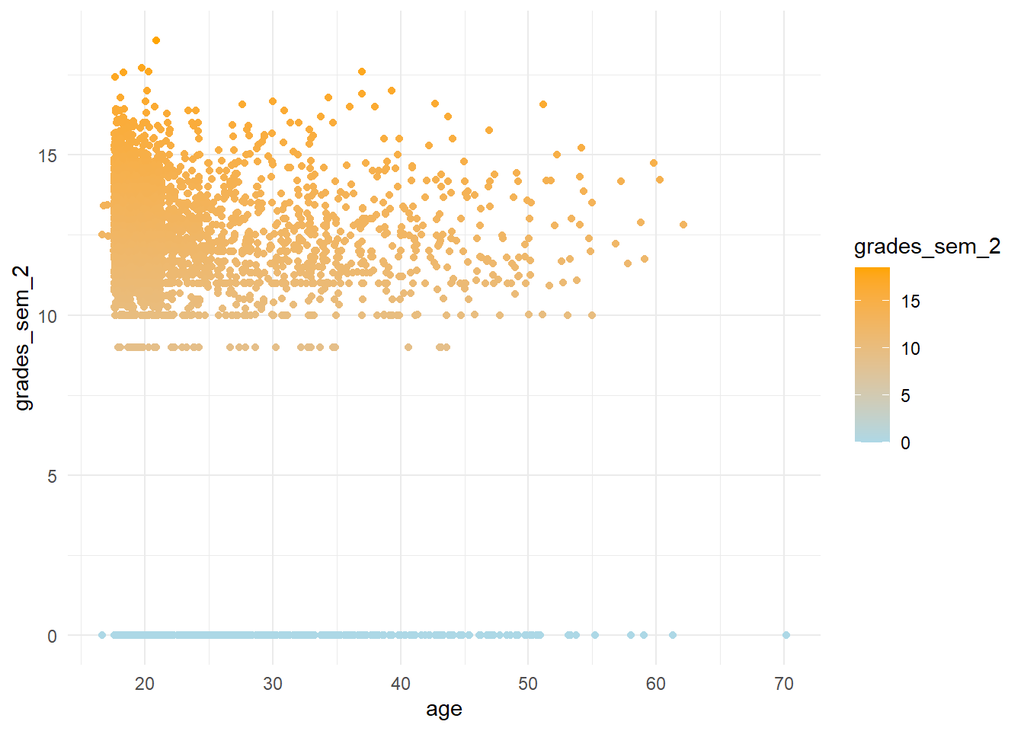

Per a les notes del segon semestre, s’observa el mateix que amb les notes del primer.

*AGE* i *NO_EVAL_SEM_1*

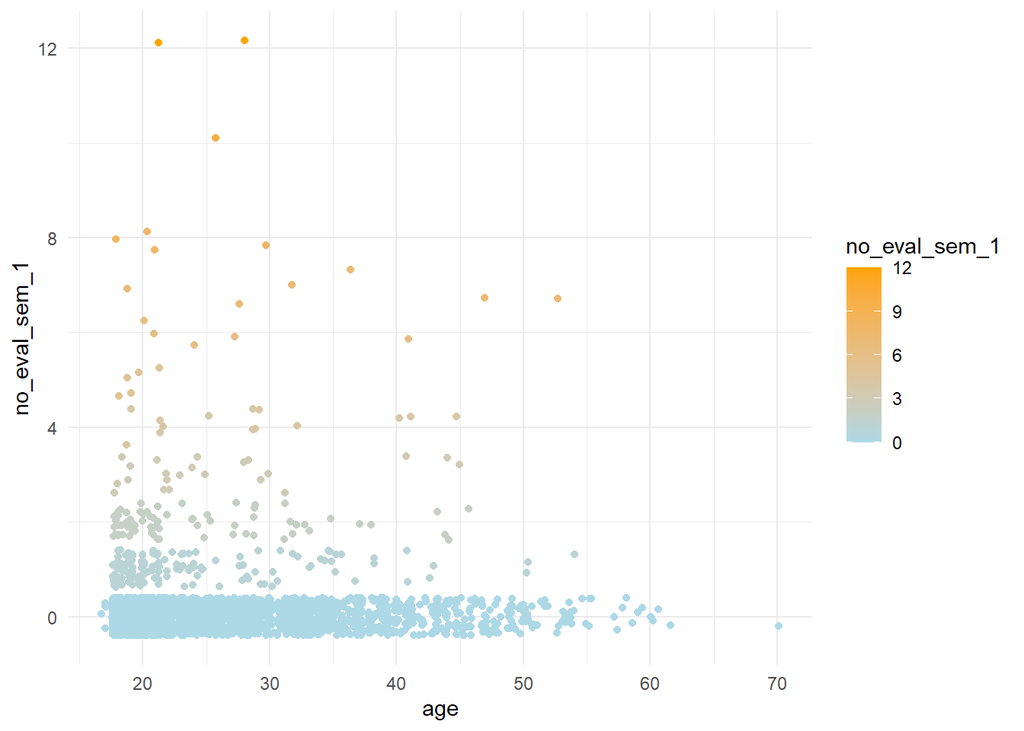

L’edat no sembla significativa respecte al nombre d’unitats no avaluades al primer semestre.